# An intro to R with an Epi working example

[Crippa Alessio](https://alecri.github.io/)

December 10th, 2019

## Aim

The aim of this document is to give a short introduction to the R software. During this tutorial I will briefly cover how to:

- read, explore and manipulate data;
- obtain summary statistics and produce informative graphics;
- fit statistical models.

The topics will be covered using the collection of packages in [tidyverse](https://www.tidyverse.org/). The real data from a cohort of marathon runners will serve as working example.

**Reference**  
[Hyponatremia among Runners in the Boston Marathon, *New England Journal of Medicine*, 2005, Volume 352:1550-1556](https://www.nejm.org/doi/full/10.1056/NEJMoa043901).

**Descriptive abstract**  
Hyponatremia has emerged as an important cause of race-related death and life-threatening illness among marathon runners. We studied a cohort of marathon runners to estimate the incidence of hyponatremia and to identify the principal risk factors.

## Load R packages

The following packages are used in the tutorial. If you want to reproduce the code chunks below, be sure to install them (e.g. `install.packages("tidyverse")`).

```r
library(tidyverse)
library(Epi)
library(knitr)
library(gridExtra)
```

## Read, explore and manipulate data

### Read data

The `marathon` data are available in a csv format at http://alecri.github.io/downloads/data/marathon.csv .

```r
marathon <- read_csv("http://alecri.github.io/downloads/data/marathon.csv")
marathon
```

```
## # A tibble: 488 x 18
##       id    na nas135 female   age urinat3p prewt postwt wtdiff height
##    <dbl> <dbl> <chr>  <chr>  <dbl> <chr>    <dbl>  <dbl>  <dbl>  <dbl>
##  1     1   138 na > … female  24.2 >=3         NA   NA       NA   1.73
##  2     2   142 na > … male    44.3 <3          NA   NA       NA  NA
##  3     3   151 na > … male    42.0 <3          NA   NA       NA  NA
##  4     4   139 na > … male    28.2 >=3         NA   NA       NA   1.73
##  5     5   145 na > … female  30.2 <3          NA   50.7     NA  NA
##  6     6   140 na > … female  28.3 <3          NA   55.7     NA   1.61
##  7     7   142 na > … male    34.4 <3          NA   59.3     NA  NA
##  8     8   140 na > … male    26.2 <3          NA   59.8     NA  NA
##  9     9   141 na > … male    50.4 <3          NA   64.8     NA  NA
## 10    10   138 na > … male    49.4 <3          NA   68.2     NA  NA
## # … with 478 more rows, and 8 more variables: bmi <dbl>, runtime <dbl>,
## #   trainpace <dbl>, prevmara <dbl>, fluidint <chr>, waterload <chr>,
## #   nsaid <chr>, wtdiffc <chr>
```

Many other options exist, such as:

- basic functions (`read.table`, `read.csv`, `read.delim`)
- from Excel `readxl::read_excel`
- from SPSS `haven::read_sav`
- from SAS `haven::read_sas`
- from Stata `haven::read_dta`

A comprehensive tutorial can be found [here](https://www.datacamp.com/community/tutorials/r-data-import-tutorial).

### Explore the data

```r
# what is the dimension of the data
dim(marathon)
```

```
## [1] 488  18
```

```r
# i.e. how many obs/rows
nrow(marathon)
```

```
## [1] 488
```

```r
# how many cols/variables?
ncol(marathon)
```

```
## [1] 18
```

```r
# what's the name of the variable
colnames(marathon)
```

```
##  [1] "id"        "na"        "nas135"    "female"    "age"
##  [6] "urinat3p"  "prewt"     "postwt"    "wtdiff"    "height"
## [11] "bmi"       "runtime"   "trainpace" "prevmara"  "fluidint"
## [16] "waterload" "nsaid"     "wtdiffc"
```

```r
# what is the structure of the data
glimpse(marathon)
```

```
## Observations: 488
## Variables: 18
## $ id        <dbl> 1, 2, 3, 4, 5, 6, 7, 8, 9, 10, 11, 12, 13, 14, 15, 16,…
## $ na        <dbl> 138, 142, 151, 139, 145, 140, 142, 140, 141, 138, 141,…
## $ nas135    <chr> "na > 135", "na > 135", "na > 135", "na > 135", "na > …
## $ female    <chr> "female", "male", "male", "male", "female", "female", …
## $ age       <dbl> 24.20534, 44.28200, 41.96304, 28.19713, 30.18207, 28.2…
## $ urinat3p  <chr> ">=3", "<3", "<3", ">=3", "<3", "<3", "<3", "<3", "<3"…
## $ prewt     <dbl> NA, NA, NA, NA, NA, NA, NA, NA, NA, NA, NA, NA, NA, NA…
## $ postwt    <dbl> NA, NA, NA, NA, 50.68182, 55.68182, 59.31818, 59.77273…
## $ wtdiff    <dbl> NA, NA, NA, NA, NA, NA, NA, NA, NA, NA, NA, NA, NA, NA…
## $ height    <dbl> 1.72720, NA, NA, 1.72720, NA, 1.60655, NA, NA, NA, NA,…
## $ bmi       <dbl> NA, NA, NA, NA, NA, NA, NA, NA, NA, NA, NA, NA, NA, NA…
## $ runtime   <dbl> NA, 161, 156, 346, 185, 233, 183, 162, 182, 190, 169, …
## $ trainpace <dbl> 480, 430, 360, 630, NA, NA, 435, 450, 435, 440, 410, 4…
## $ prevmara  <dbl> 3, 40, 40, 1, 3, 25, 19, 2, 80, 10, 16, 3, 2, 8, 4, 3,…
## $ fluidint  <chr> "Every mile", "Every mile", "Every other mile", "Every…
## $ waterload <chr> "Yes", "Yes", NA, "Yes", "Yes", "Yes", "Yes", "No", "Y…
## $ nsaid     <chr> "Yes", "Yes", NA, "No", "Yes", "No", "Yes", "No", "Yes…
## $ wtdiffc   <chr> NA, NA, NA, NA, NA, NA, NA, NA, NA, NA, NA, NA, NA, NA…
```

```r
# show the first rows
head(marathon)
```

```
## # A tibble: 6 x 18
##      id    na nas135 female   age urinat3p prewt postwt wtdiff height   bmi
##   <dbl> <dbl> <chr>  <chr>  <dbl> <chr>    <dbl>  <dbl>  <dbl>  <dbl> <dbl>
## 1     1   138 na > … female  24.2 >=3         NA   NA       NA   1.73    NA
## 2     2   142 na > … male    44.3 <3          NA   NA       NA  NA       NA
## 3     3   151 na > … male    42.0 <3          NA   NA       NA  NA       NA
## 4     4   139 na > … male    28.2 >=3         NA   NA       NA   1.73    NA
## 5     5   145 na > … female  30.2 <3          NA   50.7     NA  NA       NA
## 6     6   140 na > … female  28.3 <3          NA   55.7     NA   1.61    NA
## # … with 7 more variables: runtime <dbl>, trainpace <dbl>, prevmara <dbl>,
## #   fluidint <chr>, waterload <chr>, nsaid <chr>, wtdiffc <chr>
```

```r
# quick and dirty summary
summary(marathon)
```

```
##        id              na           nas135             female
##  Min.   :  1.0   Min.   :114.0   Length:488         Length:488
##  1st Qu.:122.8   1st Qu.:138.0   Class :character   Class :character
##  Median :244.5   Median :141.0   Mode  :character   Mode  :character
##  Mean   :244.5   Mean   :140.4
##  3rd Qu.:366.2   3rd Qu.:143.0
##  Max.   :488.0   Max.   :158.0
##
##       age          urinat3p             prewt            postwt
##  Min.   :19.44   Length:488         Min.   : 42.05   Min.   : 42.73
##  1st Qu.:31.40   Class :character   1st Qu.: 60.00   1st Qu.: 60.17
##  Median :38.80   Mode  :character   Median : 68.64   Median : 67.95
##  Mean   :38.85                      Mean   : 69.26   Mean   : 68.62
##  3rd Qu.:45.71                      3rd Qu.: 75.91   3rd Qu.: 75.23
##  Max.   :73.08                      Max.   :101.82   Max.   :100.00
##  NA's   :2                          NA's   :19       NA's   :20
##      wtdiff            height           bmi           runtime
##  Min.   :-7.0454   Min.   :1.511   Min.   :16.77   Min.   :142.0
##  1st Qu.:-1.7756   1st Qu.:1.676   1st Qu.:21.16   1st Qu.:195.0
##  Median :-0.6818   Median :1.727   Median :22.54   Median :220.0
##  Mean   :-0.6895   Mean   :1.734   Mean   :22.94   Mean   :225.5
##  3rd Qu.: 0.4546   3rd Qu.:1.800   3rd Qu.:24.25   3rd Qu.:248.0
##  Max.   : 4.0909   Max.   :2.108   Max.   :32.21   Max.   :400.0
##  NA's   :33        NA's   :18      NA's   :23      NA's   :11
##    trainpace        prevmara         fluidint          waterload
##  Min.   :330.0   Min.   :  0.000   Length:488         Length:488
##  1st Qu.:450.0   1st Qu.:  2.000   Class :character   Class :character
##  Median :480.0   Median :  5.000   Mode  :character   Mode  :character
##  Mean   :488.8   Mean   :  8.839
##  3rd Qu.:525.0   3rd Qu.: 10.000
##  Max.   :780.0   Max.   :120.000
##  NA's   :59      NA's   :3
##     nsaid             wtdiffc
##  Length:488         Length:488
##  Class :character   Class :character
##  Mode  :character   Mode  :character
##
##
##
##
```

### Manipulate data

Data manipulations consist of a multiplicity and combinations of steps. The `dplyr` package in `tidyverse` aids this task with a collections of *verbs*.  
I will show how to:

1. create/modify variables with the `mutate` verb.

```r
# run time in hour
marathon <- mutate(marathon, runtime_h = runtime/60)
# alternative code
# marathon$runtime_h <- marathon$runtime/60
```

```r
# modify a character variable into a factor variable
str(marathon$nas135)
```

```
##  chr [1:488] "na > 135" "na > 135" "na > 135" "na > 135" "na > 135" ...
```

```r
marathon <- mutate(marathon, nas135 = factor(nas135, levels = c("na > 135", "na <= 135")))
str(marathon$nas135)
```

```
##  Factor w/ 2 levels "na > 135","na <= 135": 1 1 1 1 1 1 1 1 1 1 ...
```

```r
# categorize a continuous variable
summary(marathon$age)
```

```
##    Min. 1st Qu.  Median    Mean 3rd Qu.    Max.    NA's
##   19.44   31.40   38.80   38.85   45.71   73.08       2
```

```r
marathon <- mutate(marathon, age_cat = cut(age, breaks = c(19, 31, 38, 45, 75)))
table(marathon$age_cat)
```

```
##
## (19,31] (31,38] (38,45] (45,75]
##     115     114     117     140
```

2. select only variables of interest with the `select` verb.

```r
# some variables + variables containing wt (shortage for weight)
marathon_sub <- select(marathon, id, na, female, bmi, runtime_h, contains("wt"))
head(marathon_sub)
```

```
## # A tibble: 6 x 9
##      id    na female   bmi runtime_h prewt postwt wtdiff wtdiffc
##   <dbl> <dbl> <chr>  <dbl>     <dbl> <dbl>  <dbl>  <dbl> <chr>
## 1     1   138 female    NA     NA       NA   NA       NA <NA>
## 2     2   142 male      NA      2.68    NA   NA       NA <NA>
## 3     3   151 male      NA      2.6     NA   NA       NA <NA>
## 4     4   139 male      NA      5.77    NA   NA       NA <NA>
## 5     5   145 female    NA      3.08    NA   50.7     NA <NA>
## 6     6   140 female    NA      3.88    NA   55.7     NA <NA>
```

3. select only some observations with the `filter` verb.

```r
female_27 <- filter(marathon_sub, female == "female", bmi > 27)
female_27
```

```
## # A tibble: 3 x 9
##      id    na female   bmi runtime_h prewt postwt wtdiff wtdiffc
##   <dbl> <dbl> <chr>  <dbl>     <dbl> <dbl>  <dbl>  <dbl> <chr>
## 1   254   138 female  27.8      5.68  71.3   69.5 -1.73  -2.0 to -1.1
## 2   355   158 female  29.3      5.5   80     79.3 -0.682 -1.0 to -0.1
## 3   470   135 female  31.7      6.67  73.6   73.6  0     0.0 to 0.9
```

4. sort data according to increasing/decreasing values of some variables with the `arrange` verb.

```r
arrange(female_27, desc(na), bmi)
```

```
## # A tibble: 3 x 9
##      id    na female   bmi runtime_h prewt postwt wtdiff wtdiffc
##   <dbl> <dbl> <chr>  <dbl>     <dbl> <dbl>  <dbl>  <dbl> <chr>
## 1   355   158 female  29.3      5.5   80     79.3 -0.682 -1.0 to -0.1
## 2   254   138 female  27.8      5.68  71.3   69.5 -1.73  -2.0 to -1.1
## 3   470   135 female  31.7      6.67  73.6   73.6  0     0.0 to 0.9
```

Chaining: wrap different functions inside each other

```r
arrange(
   filter(
      select(
         mutate(marathon,
                runtime_h = runtime/60),
         id, na, female, bmi, runtime_h, contains("wt")),
      female == "female", bmi > 27), desc(na), bmi)
```

```
## # A tibble: 3 x 9
##      id    na female   bmi runtime_h prewt postwt wtdiff wtdiffc
##   <dbl> <dbl> <chr>  <dbl>     <dbl> <dbl>  <dbl>  <dbl> <chr>
## 1   355   158 female  29.3      5.5   80     79.3 -0.682 -1.0 to -0.1
## 2   254   138 female  27.8      5.68  71.3   69.5 -1.73  -2.0 to -1.1
## 3   470   135 female  31.7      6.67  73.6   73.6  0     0.0 to 0.9
```

#### The %>% (pipe) operator

This operator allows you to pipe the output from one function to the input of another function.

```r
marathon %>%
   mutate(runtime_h = runtime/60) %>%
   select(id, na, female, bmi, runtime_h, contains("wt")) %>%
   filter(female == "female", bmi > 27) %>%
   arrange(desc(na), bmi)
```

```
## # A tibble: 3 x 9
##      id    na female   bmi runtime_h prewt postwt wtdiff wtdiffc
##   <dbl> <dbl> <chr>  <dbl>     <dbl> <dbl>  <dbl>  <dbl> <chr>
## 1   355   158 female  29.3      5.5   80     79.3 -0.682 -1.0 to -0.1
## 2   254   138 female  27.8      5.68  71.3   69.5 -1.73  -2.0 to -1.1
## 3   470   135 female  31.7      6.67  73.6   73.6  0     0.0 to 0.9
```

## Summary statistics and graphs

### ggplot2: grammar of graphics

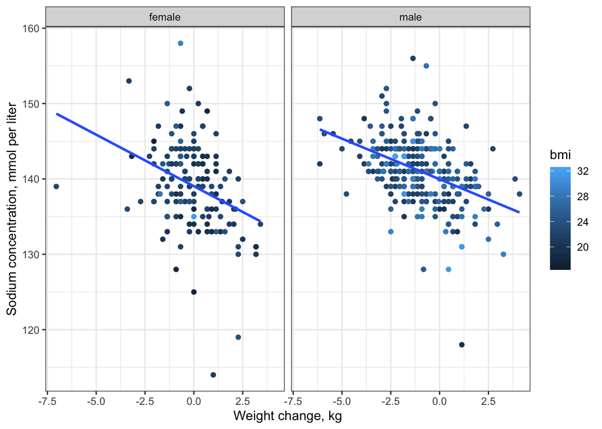

```r
ggplot(marathon, aes(wtdiff, na, col = bmi)) +
  geom_point() +
  geom_smooth(method = "lm", se = FALSE) +
  facet_wrap(~ female) +
  labs(x = "Weight change, kg", y = "Sodium concentration, mmol per liter") +
  theme_bw()
```

```r
# change theme for next graphs
theme_set(theme_bw())
```

### Univariate descriptives

```r
# for a continuous variable
summary(marathon$na)
```

```
##    Min. 1st Qu.  Median    Mean 3rd Qu.    Max.
##   114.0   138.0   141.0   140.4   143.0   158.0
```

```r
c(mean = mean(marathon$na), sd = sd(marathon$na))
```

```
##       mean         sd
## 140.405738   4.752102
```

```r
quantile(marathon$na)
```

```
##   0%  25%  50%  75% 100%
##  114  138  141  143  158
```

```r
summarise(marathon, mean = mean(na), sd = sd(na), median = median(na), iqr = IQR(na))
```

```
## # A tibble: 1 x 4
##    mean    sd median   iqr
##   <dbl> <dbl>  <dbl> <dbl>
## 1  140.  4.75    141     5
```

```r
# more concise
summarise_each(marathon, funs(mean, sd, median, IQR), na)
```

```
## # A tibble: 1 x 4
##    mean    sd median   IQR
##   <dbl> <dbl>  <dbl> <dbl>
## 1  140.  4.75    141     5
```

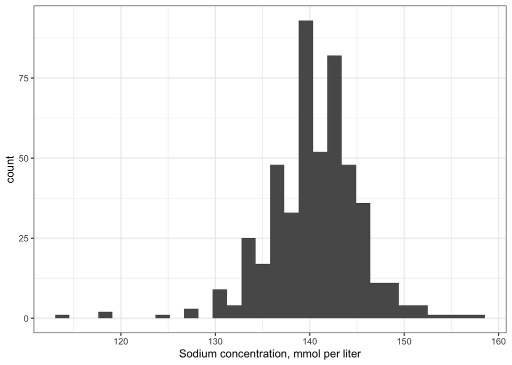

```r
# histogram (counts)
ggplot(marathon, aes(na)) +
  geom_histogram() +
  labs(x = "Sodium concentration, mmol per liter")
```

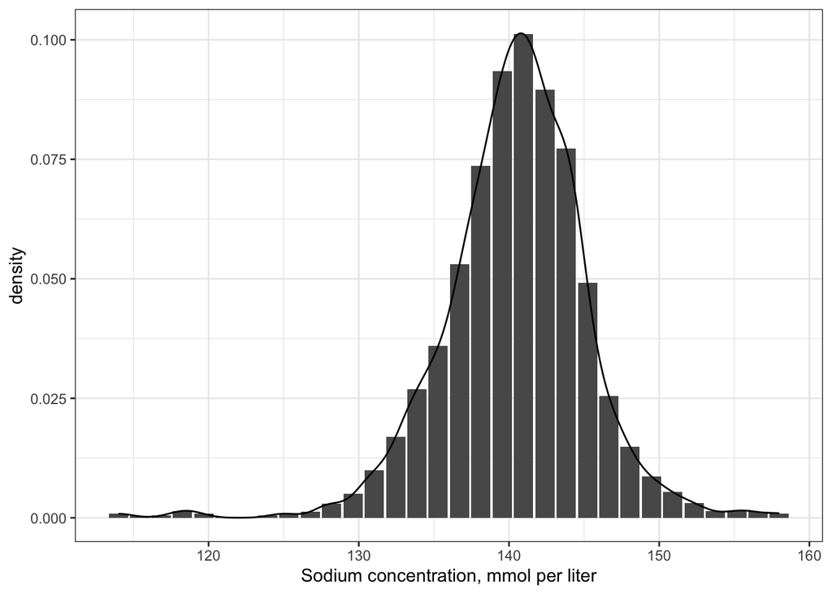

```r
# histogram (density)
ggplot(marathon, aes(na)) +
  geom_histogram(stat = "density", n = 2^5) +
  geom_line(stat = "density") +
    labs(x = "Sodium concentration, mmol per liter")
```

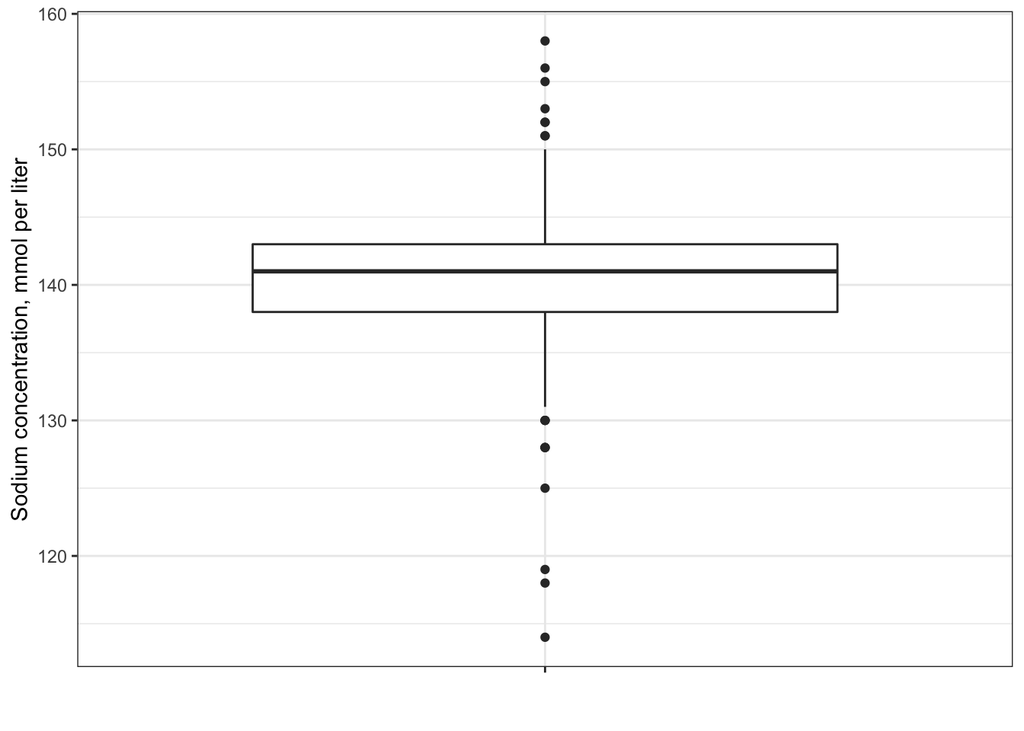

```r
# boxplot
ggplot(marathon, aes(x = "", y = na)) +
  geom_boxplot() +
  labs(x = "", y = "Sodium concentration, mmol per liter")
```

```r
# for a categorical variable
table(marathon$nas135)
```

```
##
##  na > 135 na <= 135
##       426        62
```

```r
prop.table(table(marathon$nas135))
```

```
##
##  na > 135 na <= 135
## 0.8729508 0.1270492
```

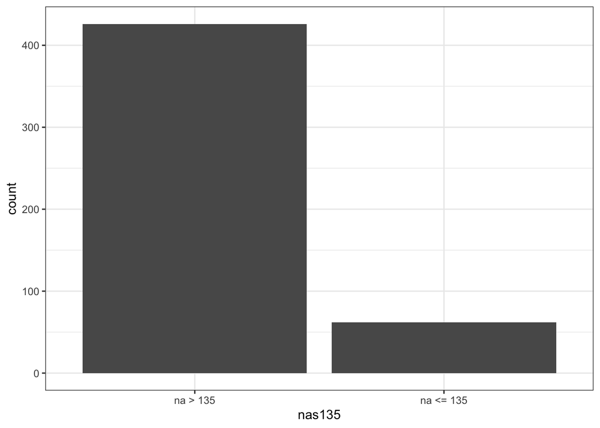

```r
# barplot (counts)
ggplot(marathon, aes(nas135)) +
  geom_bar()
```

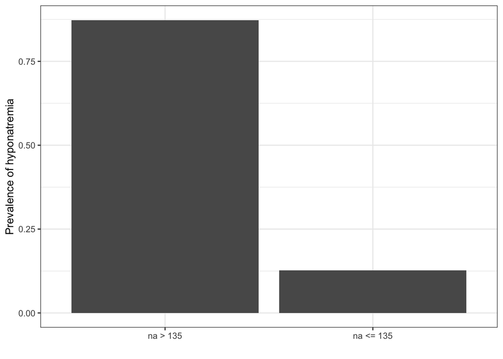

```r
# barplot (proportion)
ggplot(marathon, aes(nas135)) +
  geom_bar(aes(y = ..count../sum(..count..))) +
  labs(x = "", y = "Prevalence of hyponatremia")
```

### Bivariate descriptives (association)

```r
# Continuous + categorical
marathon %>%
  group_by(female) %>%
  summarise_each(funs(mean, sd, median, IQR), na)
```

```
## # A tibble: 2 x 5
##   female  mean    sd median   IQR
##   <chr>  <dbl> <dbl>  <dbl> <dbl>
## 1 female  139.  5.55    139  6.75
## 2 male    141.  4.15    141  5
```

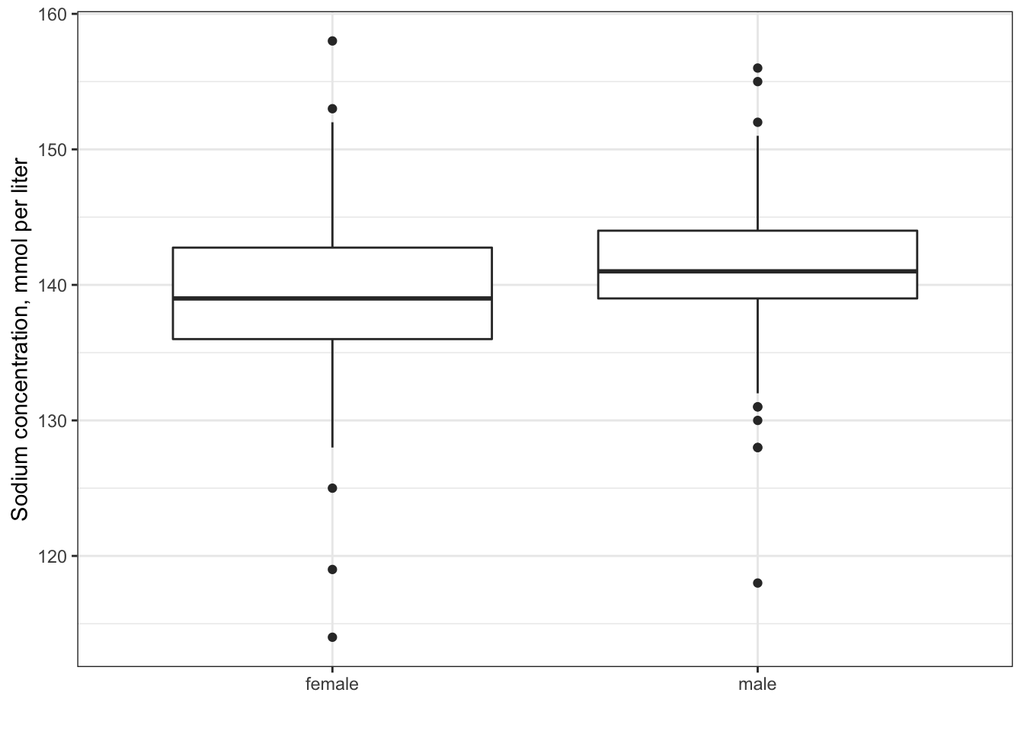

```r
ggplot(marathon, aes(female, na)) +
  geom_boxplot() +
  labs(x = "", y = "Sodium concentration, mmol per liter")
```

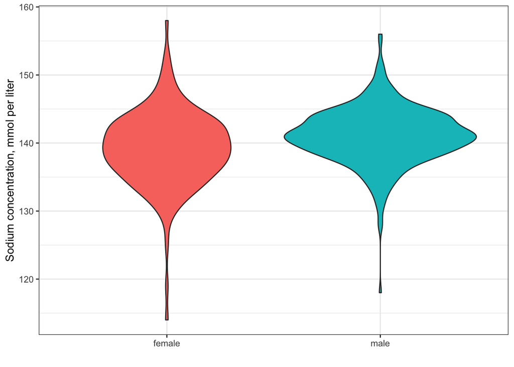

```r
ggplot(marathon, aes(female, na, fill = female)) +
  geom_violin() +
  guides(fill = "none") +
    labs(x = "", y = "Sodium concentration, mmol per liter")
```

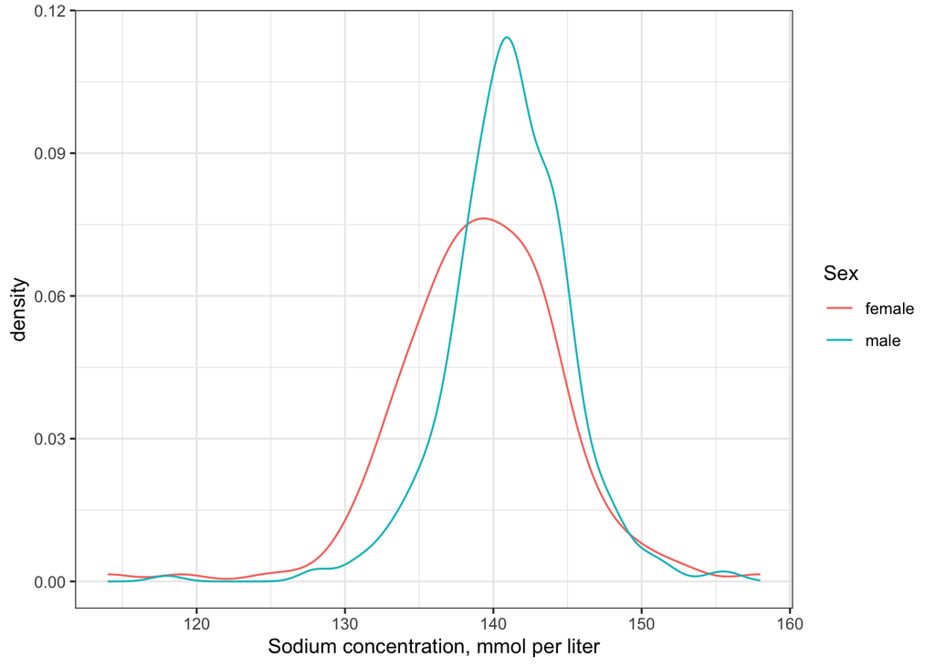

```r
ggplot(marathon, aes(na, col = female)) +
  geom_line(stat = "density") +
  labs(x = "Sodium concentration, mmol per liter", col = "Sex")
```

```r
# statistical tests
t.test(na ~ female, data = marathon, var.equal = FALSE)
```

```
##
##  Welch Two Sample t-test
##
## data:  na by female
## t = -3.8169, df = 262.95, p-value = 0.0001686
## alternative hypothesis: true difference in means is not equal to 0
## 95 percent confidence interval:
##  -2.8281299 -0.9032178
## sample estimates:
## mean in group female   mean in group male
##             139.1747             141.0404
```

```r
wilcox.test(na ~ female, data = marathon)
```

```
##
##  Wilcoxon rank sum test with continuity correction
##
## data:  na by female
## W = 20450, p-value = 1.996e-05
## alternative hypothesis: true location shift is not equal to 0
```

```r
# 2-by-2 table
tab1 <- with(marathon, table(nas135, female))
tab1
```

```
##            female
## nas135      female male
##   na > 135     129  297
##   na <= 135     37   25
```

```r
prop.table(tab1, margin = 2)
```

```
##            female
## nas135          female       male
##   na > 135  0.77710843 0.92236025
##   na <= 135 0.22289157 0.07763975
```

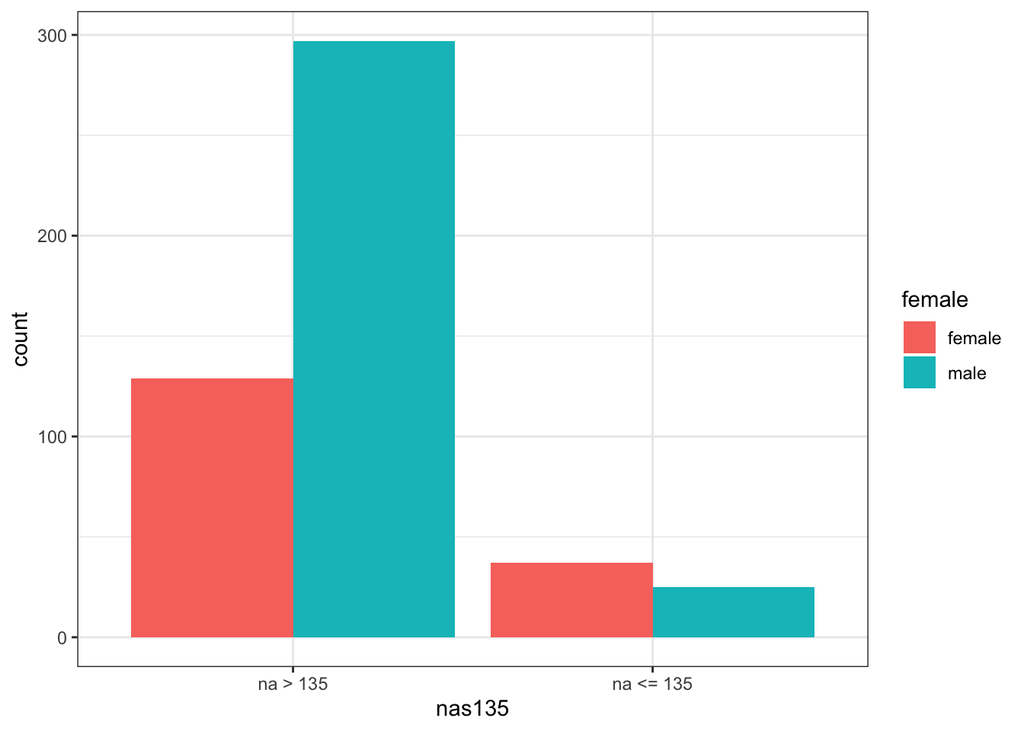

```r
ggplot(marathon, aes(nas135, fill = female)) +
  geom_bar(position = "dodge")
```

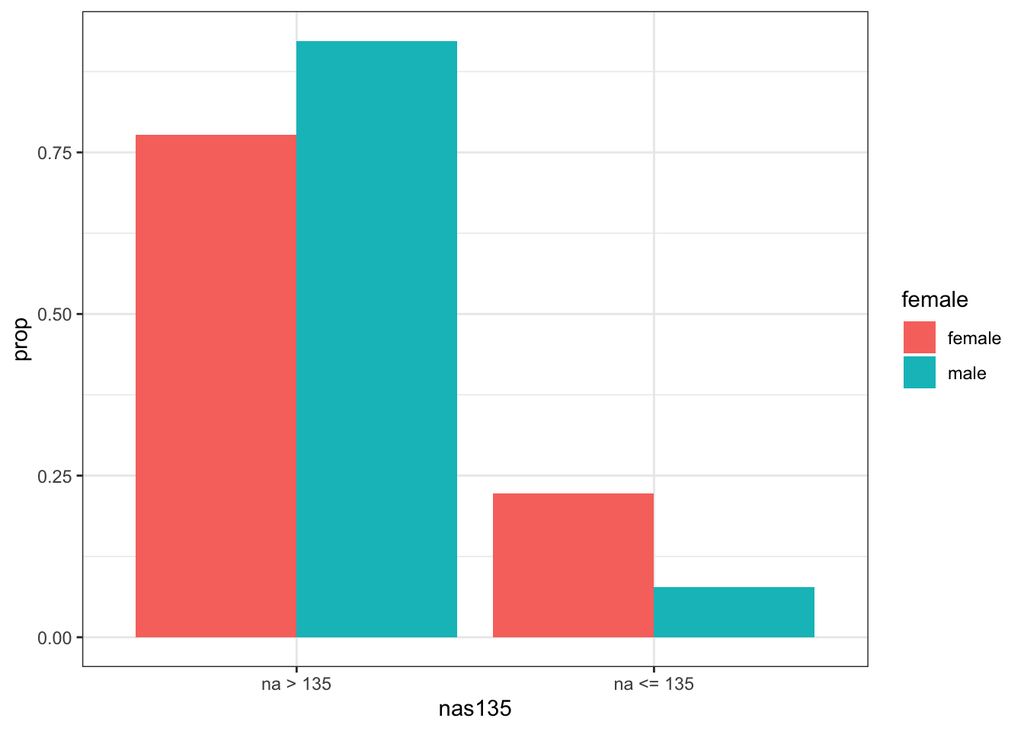

```r
ggplot(marathon, aes(nas135, group = female, fill = female)) +
  geom_bar(aes(y = ..prop..), position = "dodge")
```

```r
# statistical tests
chisq.test(tab1)
```

```
##
##  Pearson's Chi-squared test with Yates' continuity correction
##
## data:  tab1
## X-squared = 19.547, df = 1, p-value = 9.813e-06
```

```r
# 2 continuous
cor_nawtd <- with(marathon, cor(na, wtdiff,  method = "pearson", use = "complete.obs"))
cor_nawtd
```

```
## [1] -0.4106029
```

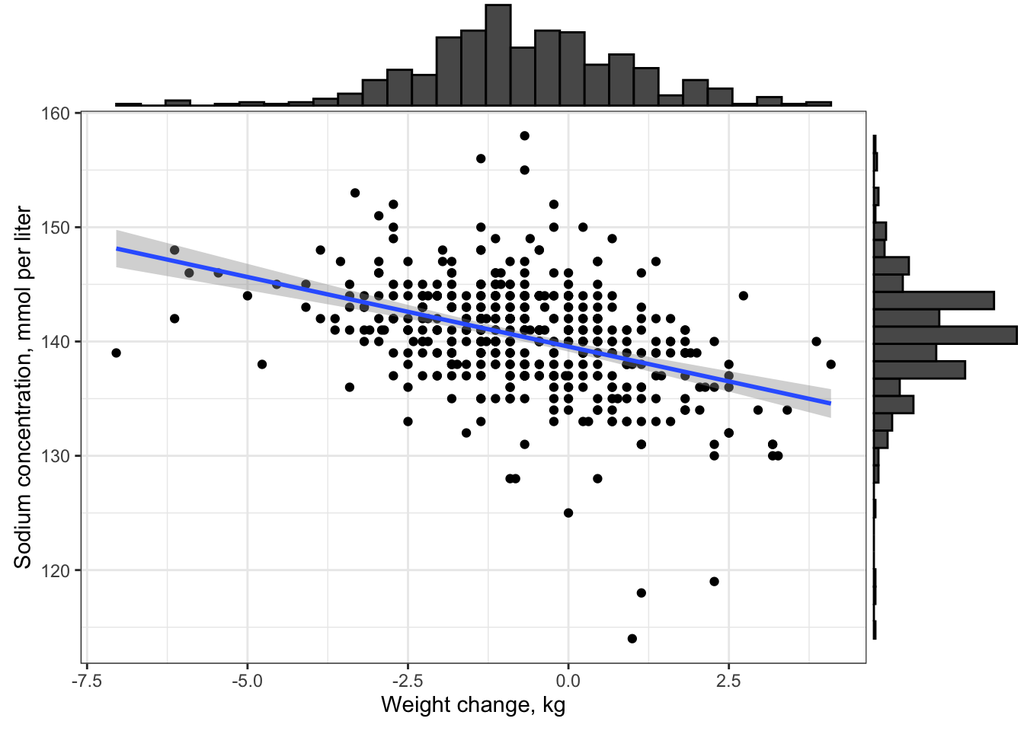

```r
p1 <- ggplot(marathon, aes(wtdiff, na)) +
  geom_point() +
  geom_smooth(method = "lm") +
  labs(x = "Weight change, kg", y = "Sodium concentration, mmol per liter")
library(ggExtra)
ggMarginal(p1, type = "histogram")
```

#### Table 1

```r
library(table1)
table1(~ age + female + wtdiff + bmi + runtime | nas135, data = marathon)
```

|  | na > 135 (n=426) | na <= 135 (n=62) | Overall (n=488) |
| --- | --- | --- | --- |
| age |  |  |  |
| Mean (SD) | 39.0 (9.40) | 38.1 (9.47) | 38.8 (9.41) |
| Median [Min, Max] | 39.1 [19.4, 73.1] | 38.1 [23.2, 60.2] | 38.8 [19.4, 73.1] |
| Missing | 2 (0.5%) | 0 (0%) | 2 (0.4%) |
| female |  |  |  |
| female | 129 (30.3%) | 37 (59.7%) | 166 (34.0%) |
| male | 297 (69.7%) | 25 (40.3%) | 322 (66.0%) |
| wtdiff |  |  |  |
| Mean (SD) | -0.892 (1.54) | 0.725 (1.44) | -0.689 (1.62) |
| Median [Min, Max] | -0.909 [-7.05, 4.09] | 0.682 [-2.50, 3.41] | -0.682 [-7.05, 4.09] |
| Missing | 28 (6.6%) | 5 (8.1%) | 33 (6.8%) |
| bmi |  |  |  |
| Mean (SD) | 23.0 (2.52) | 22.8 (3.71) | 22.9 (2.70) |
| Median [Min, Max] | 22.6 [17.0, 32.2] | 22.3 [16.8, 31.7] | 22.5 [16.8, 32.2] |
| Missing | 21 (4.9%) | 2 (3.2%) | 23 (4.7%) |
| runtime |  |  |  |
| Mean (SD) | 222 (39.4) | 252 (47.1) | 226 (41.6) |
| Median [Min, Max] | 216 [142, 360] | 242 [159, 400] | 220 [142, 400] |
| Missing | 9 (2.1%) | 2 (3.2%) | 11 (2.3%) |

## Statistical models

### Linear regression

$$E[Y|X] = \beta_0 + \beta_1X_1 + \dots + \beta_kX_k$$

```r
# univariate linear regression
fit1 <- lm(na ~ female, data = marathon)
summary(fit1)
```

```
##
## Call:
## lm(formula = na ~ female, data = marathon)
##
## Residuals:
##      Min       1Q   Median       3Q      Max
## -25.1747  -2.1747  -0.0404   2.9596  18.8253
##
## Coefficients:
##             Estimate Std. Error t value Pr(>|t|)
## (Intercept) 139.1747     0.3628 383.657  < 2e-16 ***
## femalemale    1.8657     0.4466   4.178 3.49e-05 ***
## ---
## Signif. codes:  0 '***' 0.001 '**' 0.01 '*' 0.05 '.' 0.1 ' ' 1
##
## Residual standard error: 4.674 on 486 degrees of freedom
## Multiple R-squared:  0.03467,    Adjusted R-squared:  0.03268
## F-statistic: 17.45 on 1 and 486 DF,  p-value: 3.492e-05
```

```r
ci.lin(fit1) %>% kable()
```

|  | Estimate | StdErr | z | P | 2.5% | 97.5% |
| --- | --- | --- | --- | --- | --- | --- |
| (Intercept) | 139.174699 | 0.3627577 | 383.657463 | 0.00e+00 | 138.4637068 | 139.885691 |
| femalemale | 1.865674 | 0.4465793 | 4.177699 | 2.94e-05 | 0.9903945 | 2.740953 |

```r
# multivariable linear regression
fit2 <- lm(na ~ wtdiff + female, data = marathon)
ci.lin(fit2) %>% kable()
```

|  | Estimate | StdErr | z | P | 2.5% | 97.5% |
| --- | --- | --- | --- | --- | --- | --- |
| (Intercept) | 139.0629967 | 0.3483380 | 399.218548 | 0.0000000 | 138.3802667 | 139.7457266 |
| wtdiff | -1.1572580 | 0.1310845 | -8.828337 | 0.0000000 | -1.4141789 | -0.9003371 |
| femalemale | 0.8158008 | 0.4452803 | 1.832106 | 0.0669356 | -0.0569325 | 1.6885341 |

```r
marathon <- mutate(marathon,
                   pred_fit2 = predict(fit2, newdata = marathon))
```

```r
# multivariable linear regression with interaction
fit3 <- lm(na ~ wtdiff*female, data = marathon)
ci.lin(fit3, ctr.mat = rbind(c(0, 1, 0, 0),
                             c(0, 1, 0, 1)))
```

```
##       Estimate    StdErr         z            P      2.5%      97.5%
## [1,] -1.366193 0.2484292 -5.499325 3.812468e-08 -1.853105 -0.8792807
## [2,] -1.076637 0.1543198 -6.976661 3.022779e-12 -1.379098 -0.7741756
```

```r
marathon <- mutate(marathon,
                   pred_fit3 = predict(fit3, newdata = marathon))
```

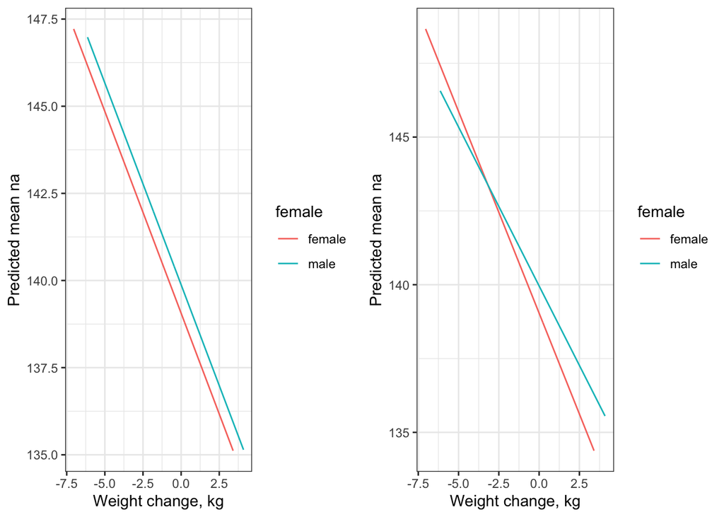

```r
# graphical comparison
grid.arrange(
  ggplot(marathon, aes(wtdiff, pred_fit2, col = female)) +
    geom_line() +
    labs(x = "Weight change, kg", y = "Predicted mean na"),
    ggplot(marathon, aes(wtdiff, pred_fit3, col = female)) +
    geom_line() +
    labs(x = "Weight change, kg", y = "Predicted mean na"),
  ncol = 2
)
```

### Logistic regression

$$\log(\textrm{odds}(Y|X)) = \beta_0 + \beta_1X_1 + \dots + \beta_kX_k$$

```r
# univariate logistic regression
fit4 <- glm(nas135 ~ wtdiff, data = marathon, family = binomial)
ci.exp(fit4)
```

```
##             exp(Est.)      2.5%     97.5%
## (Intercept) 0.1518239 0.1112437 0.2072074
## wtdiff      2.0717812 1.6689660 2.5718185
```

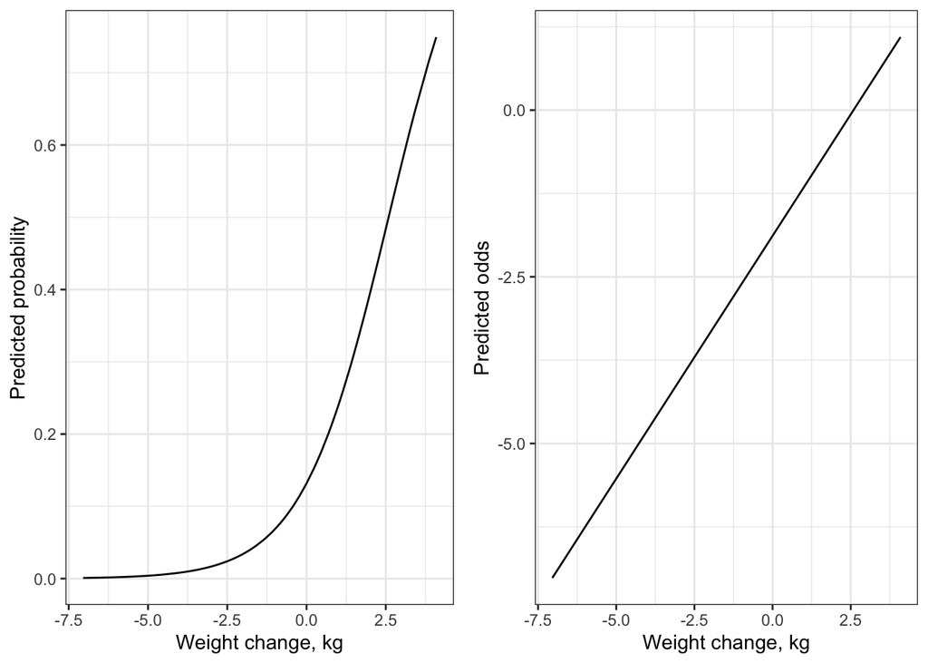

```r
marathon <- marathon %>%
  mutate(pred_p = predict(fit4, newdata = marathon, type = "response"),
         pred_odds = predict(fit4, newdata = marathon, type = "link"))
grid.arrange(
  ggplot(marathon, aes(wtdiff, pred_p)) +
    geom_line() +
    labs(x = "Weight change, kg", y = "Predicted probability"),
  ggplot(marathon, aes(wtdiff, pred_odds)) +
    geom_line() +
    labs(x = "Weight change, kg", y = "Predicted odds"),
  ncol = 2
)
```

```r
# multivariable logistic regression
fit5 <- glm(nas135 ~ wtdiff + female, data = marathon, family = binomial)
ci.exp(fit5)
```

```
##             exp(Est.)      2.5%     97.5%
## (Intercept) 0.2389491 0.1572127 0.3631810
## wtdiff      2.0189387 1.6152028 2.5235924
## femalemale  0.4191424 0.2278755 0.7709486
```

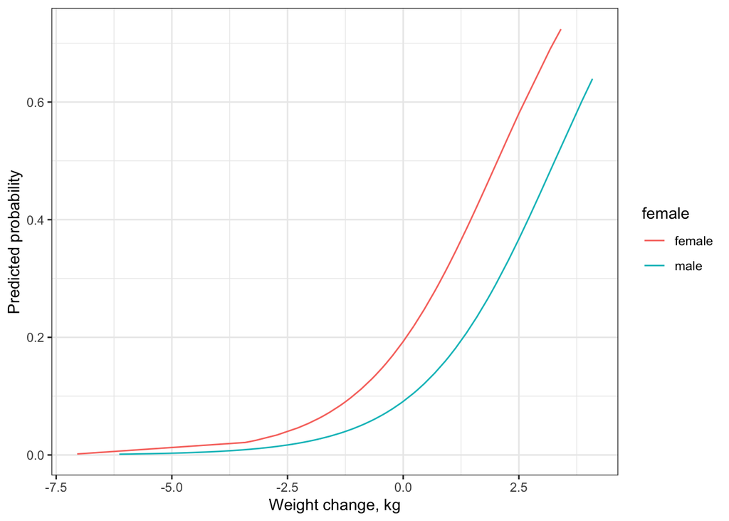

```r
mutate(marathon, pred = predict(fit5, newdata = marathon, type = "response")) %>%
  ggplot(aes(wtdiff, pred, col = female)) +
  geom_line() +
  labs(x = "Weight change, kg", y = "Predicted probability")
```